# Teporales Data Mining, SS 2016

Projekt 2, Wissen aus Hydrologie

Benjamin Roesner, Marta Lemanczyk, Jiachun Zhang

# 1 Inspizieren sie die einzelnen Zeitreihen mit den Methoden der Knowledge Discovery

Zur Untersuchung sind Datensätze „Chirimachay_NO3.lrn“ , „Chirimachay_Netradiation.lrn“ und „Chirimachay_Precip.lrn“. Die Datensätze sind jeweils Liste mit 7 Variablen, so dass die Messungswerte und Messungszeiten genau notiert werden.

## 1.1 Chirimachay_NO3

[output not shown]

```
##        NNO3mgl MMDDHHMin YYYY MM DD HH Min
## 22686 0.028200   8300008 2015  8 30  0  30
## 22687 0.032167   8300108 2015  8 30  1   0
## 22688 0.032143   8300108 2015  8 30  1  30
## 22689 0.030800   8300208 2015  8 30  2   0
## 22690 0.030000   8300208 2015  8 30  2  30
## 22691 0.032000   8300308 2015  8 30  3   0
## 22692 0.029400   8300308 2015  8 30  3  30
## 22693 0.029500   8300408 2015  8 30  4   0
## 22694 0.030143   8300408 2015  8 30  4  30
## 22695 0.029000   8300508 2015  8 30  5   0
```

Es sind insgesamt 22695 Werte jede 30 Minuten von 10 Uhr, 14.5.2014 bis 5 Uhr, 30.8.2015 gemessen worden. Die Zeitreihe verläuft steitg, vorbei einige Fehlstellen durch Intepolation ersetzt werden kann, da es gibt Sprungen zwischen Zeitpunkten zu beobachten hat. Die Zeitreihe ist nicht stationär, auch hetroskedastisch, daher ist die auch kein weißes Rauschen. Für die Verteilung der zeitunabhängige Beobachtungswerte „NNO3mgl“ wirde folgende Histogramm, PDE plot, QQ-plot gegen Normalverteilung, Boxplot sowie das Barplot für NaNs ausgegeben.

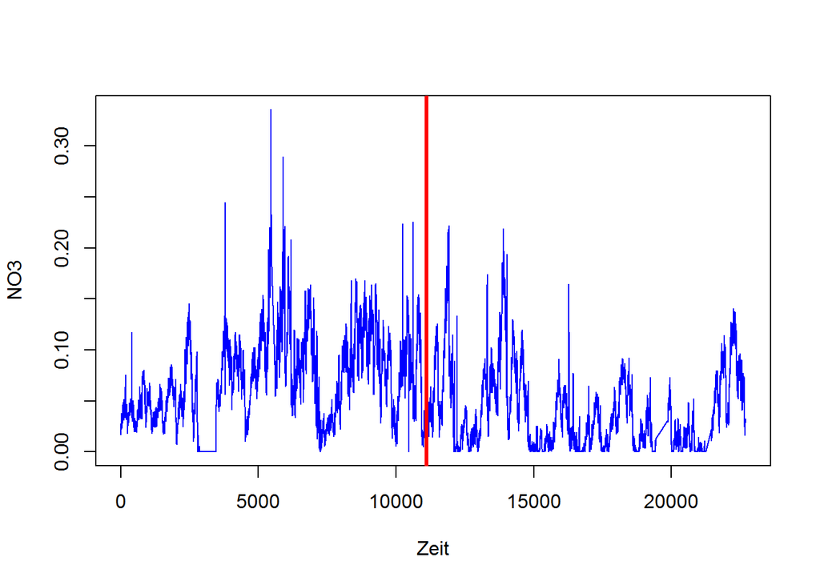

Figure 1: Ueberblick von Zeitreihe NO3

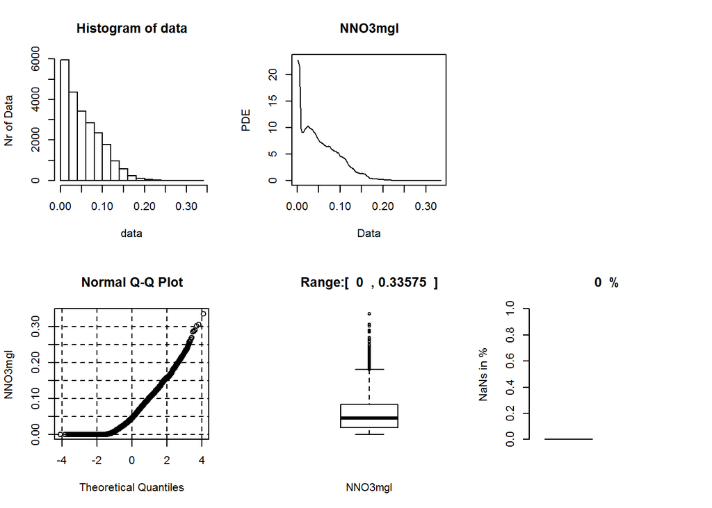

Figure 2: Visuelle Inspektion NO3

- Keine NaNs, Es gibt ganz vielen Nullen. → NaNs durch Nullen eingesetzt.
- Wertbereich sehr klein.
- Nicht normalverteilt.

Versuche jetzt die Nullen wegzunehmen.

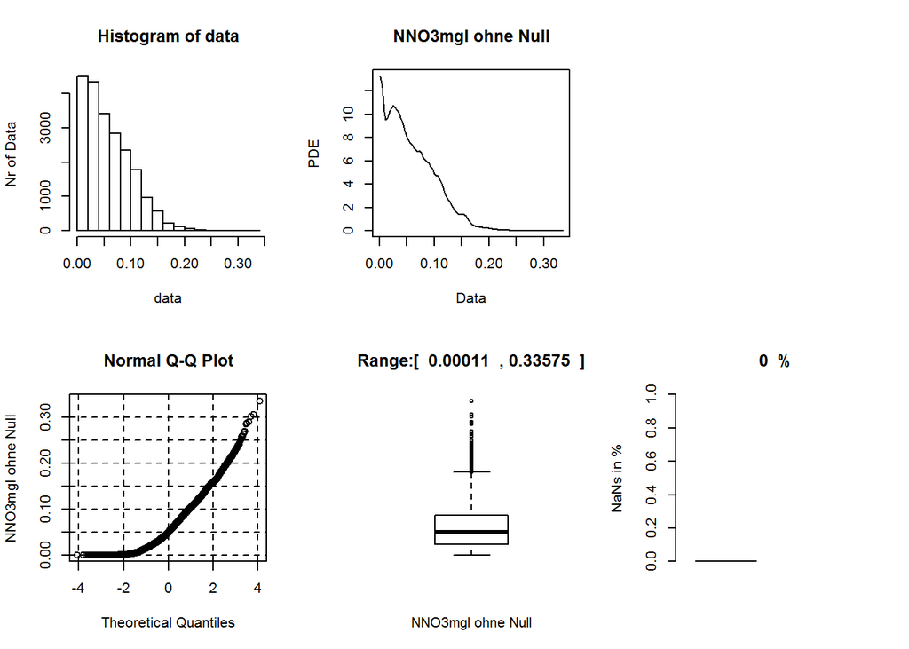

Figure 3: Visuelle Inspektion NO3 ohne Nullen

- nach Eliminierung der Nullen ist es deutlich, dass es sich um einen Wachstum handelt. -> logaritmieren?
- Wertbereich sehr klein → prozentuierung

Nach mehrfach Durfühung der Box-cox Transformation hat Faktor 0,5 als Empfehlung erhalten:

```
## $LambdaMatrix
##       sw  ad cvm  pt  sf  lt  jb  ac
## [1,] 0.5 0.5 0.5 0.4 0.5 0.5 0.5 0.4
##
## $boxcoxncData
## $boxcoxncData$title
## [1] "Implementation of Box-Cox Power Transformation when No Covariate Is Available"
##
## $boxcoxncData$method
## [1] "All"
##
## $boxcoxncData$date
## [1] "Thu Jun 16 01:59:11 2016"
##
## $boxcoxncData$result
##                      sw           ad          cvm           pt
## lambda.hat 5.000000e-01 5.000000e-01 5.000000e-01 4.000000e-01
## sw.pvalue  4.579670e-15 4.579670e-15 4.579670e-15 4.351134e-17
## sf.pvalue  5.229516e-15 5.229516e-15 5.229516e-15 1.080597e-16
## jb.pvalue  4.579670e-15 4.579670e-15 4.579670e-15 0.000000e+00
##                      sf           lt           jb           ac
## lambda.hat 5.000000e-01 5.000000e-01 5.000000e-01 4.000000e-01
## sw.pvalue  4.579670e-15 4.579670e-15 4.579670e-15 4.351134e-17
## sf.pvalue  5.229516e-15 5.229516e-15 5.229516e-15 1.080597e-16
## jb.pvalue  4.579670e-15 4.579670e-15 4.579670e-15 0.000000e+00
```

Betrachte daher die Transformation (Wurzel(Daten)*100):

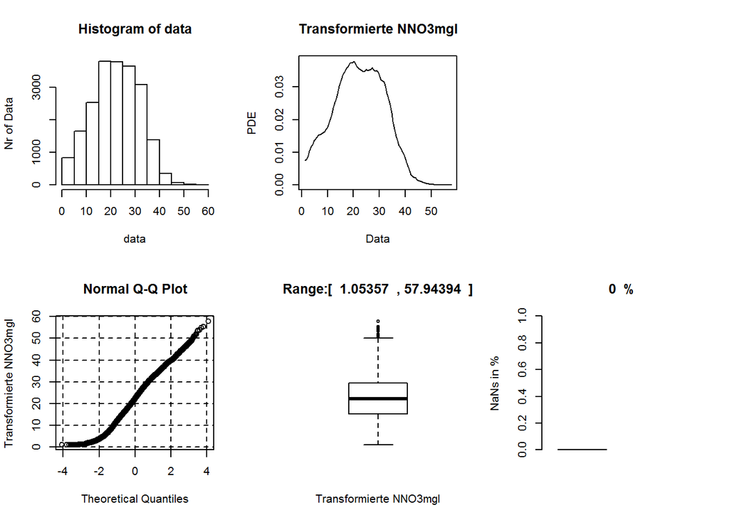

Figure 5: Visuelle Inspektion transformierte NO3 ohne Nullen

- Die Approximation in der Mitte sehr gut, bei kleiner Werte ist Approximation sehr schlecht. Muss erneut angepasst werden.
- Gaussian Mixture Modell

### 1.1.1 GMM

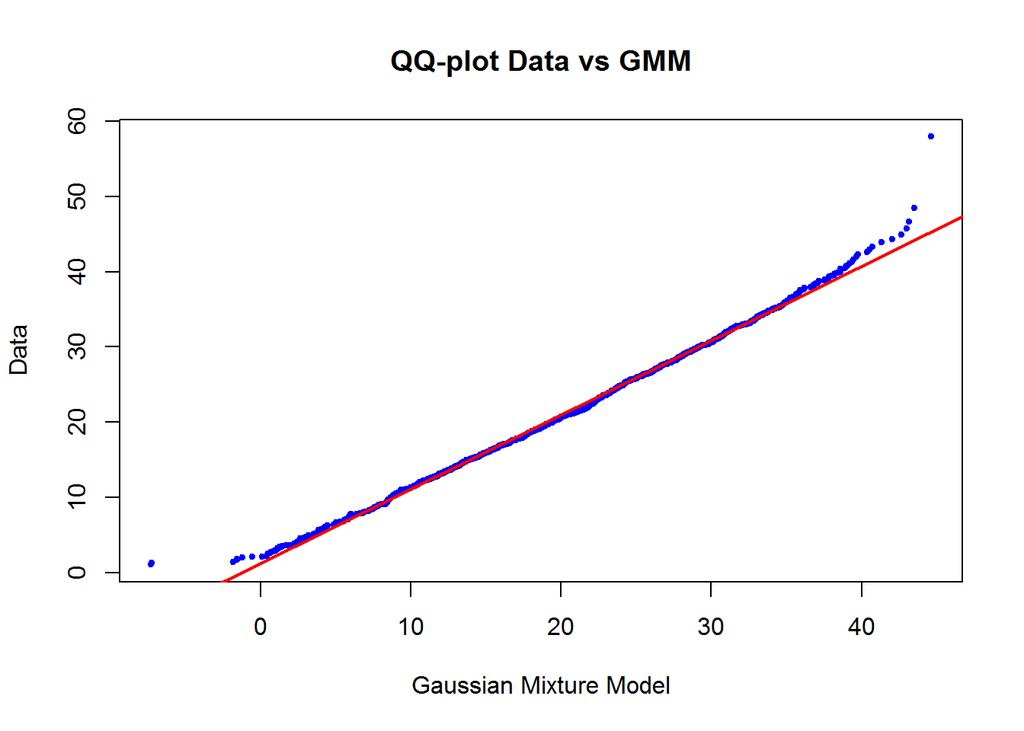

Figure 6: QQplot zur Verifizierung, Daten gegen GMM

Hier sieht man, dass die Anpassung bei der extrem Werte Bereich immer noch schlecht ist. Betrachte noch die statistische Verifizierung.

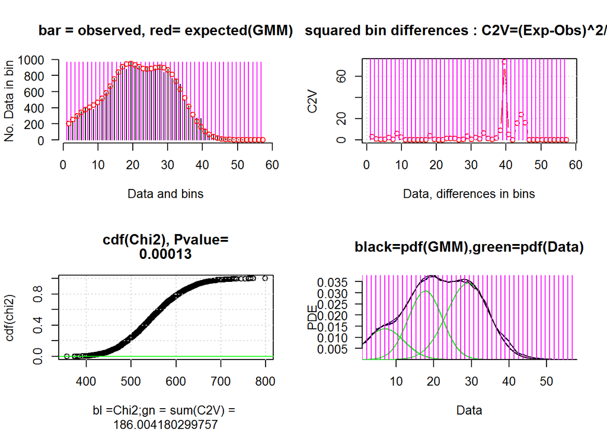

Figure 7: Chi-Quadrat-Test. H0: Daten und GMM besitzen die gleiche Verteilung

### 1.1.2 Clusterung der Daten

Die Beobachtung kann zu vier Klassen geteilt werden, Niedrige Stoffkonzentration, mittele Stoffkonzentration hoch Stoffkonzentration sowie die Nullen.

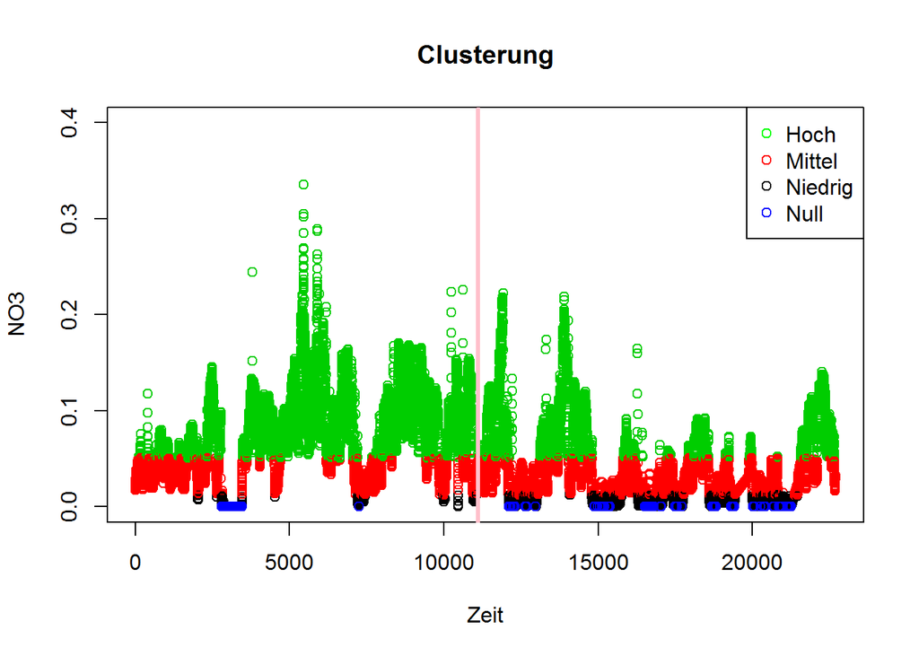

Figure 8: Clusterung nach GMM, Nullen bilden sich als eine Gruppe

### 1.1.3 ARCH/GARCH

Betrachte Differenzreihe, da die Zeitreihe stationär sein muss.

ARCH LM-Test, teste, ob ARCH Effekte gibt:

```
##
##  ARCH LM-test; Null hypothesis: no ARCH effects
##
## data:  Differenz
## Chi-squared = 3873.3, df = 12, p-value < 2.2e-16
```

Nullhypothese wird abgelehnt, es gibt ARCH Effekt.

Die Parameter wird hier durch Anprobieren bestimmt, dann durch AIC Kriterium das beste Parameter bestimmt.

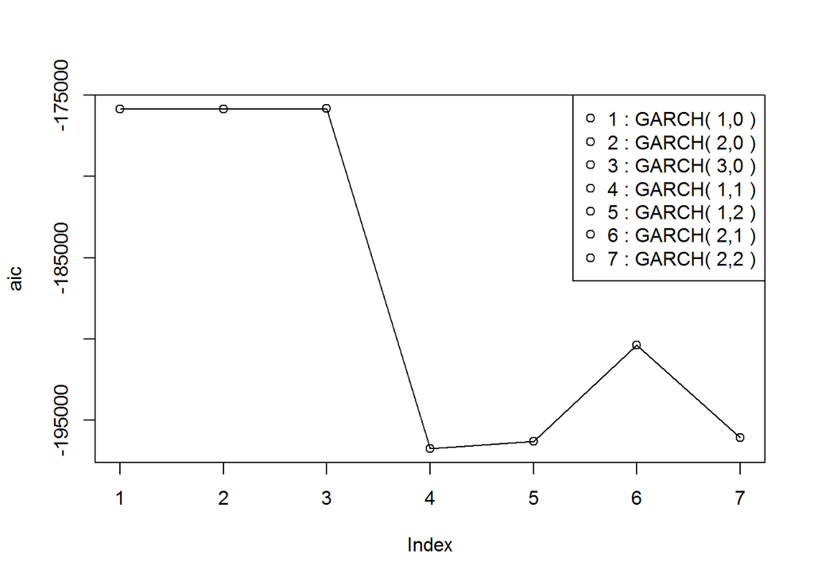

Figure 9: Güte des GARCH Modelles mit unterschiedliche Parameter

Also hier wird GARCH(1,1) ausgewählt.

```
##
## Call:
## garch(x = Differenz, order = c(1, 1))
##
## Model:
## GARCH(1,1)
##
## Residuals:
##      Min       1Q   Median       3Q      Max
## -26.5134  -0.5172   0.0000   0.5177  26.8538
##
## Coefficient(s):
##     Estimate  Std. Error  t value Pr(>|t|)
## a0 1.081e-08          NA       NA       NA
## a1 3.285e-01          NA       NA       NA
## b1 7.722e-01          NA       NA       NA
##
## Diagnostic Tests:
##  Jarque Bera Test
##
## data:  Residuals
## X-squared = 5872800, df = 2, p-value < 2.2e-16
##
##
##  Box-Ljung test
##
## data:  Squared.Residuals
## X-squared = 0.17255, df = 1, p-value = 0.6779
```

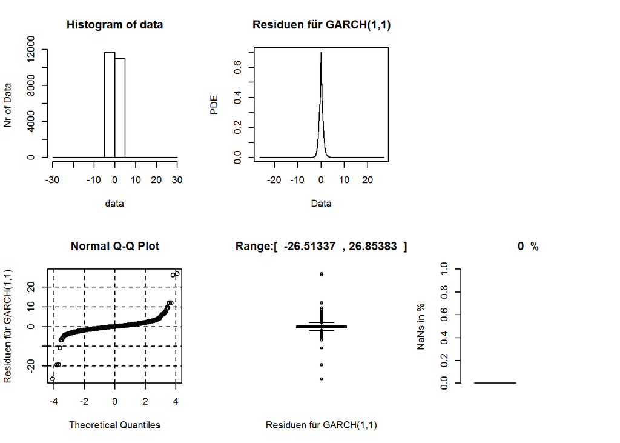

Figure 10: Residuenanalysis für GARCH(1,1)

Jarque Bera Test ist ein statistischer Test, der anhand der Schiefe und der Kurtosis in den Daten prüft, ob eine Normalverteilung vorliegt. Hier zeigt, dass die Residuen keine Normalverteilung ist. **Nach des Skripts muss Residuen $\chi^2$ verteilt sein.** Die PDEplot zeigt keine $\chi^2$ Verteilung.

Box-Ljung Test testet auf der Autokorelation, hier zeigt keine Autokorelation innerhalb der Residuen. Laut des Skripts sollen Risiduen keine Autokorrelation unterliegen, daher stellt das GARCH(1,1) eine gute Anpassung dar.

## 1.2 Chirimachay_Precip

[output not shown]

```
##       PrecipitationMM MMDDHHMin YYYY MM DD HH Min
## 34061             0.0  12140312   15 12 14  3  30
## 34062             0.0  12140412   15 12 14  4   0
## 34063             0.0  12140412   15 12 14  4  30
## 34064             0.0  12140512   15 12 14  5   0
## 34065             0.0  12140512   15 12 14  5  30
## 34066             0.1  12140612   15 12 14  6   0
## 34067             0.1  12140612   15 12 14  6  30
## 34068             0.1  12140712   15 12 14  7   0
## 34069             0.1  12140712   15 12 14  7  30
## 34070             0.1  12140812   15 12 14  8   0
```

Es sind insgesamt 34070 Werte jede 30 Minuten von 13:30 Uhr, 3.1.2014 bis 8 Uhr, 14.12.2015 gemessen worden. Meisten Daten sind entweder 0,0 oder 0,1. Geneuer ist 84% der Daten 0,0, und 15% der Daten hat der Wert 0,1.

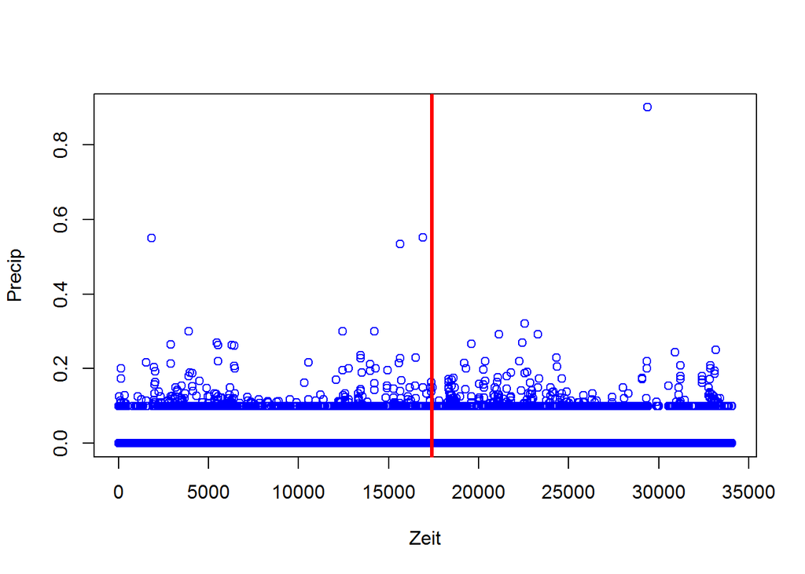

Figure 11: Ueberblick von Zeitreihe Precipitation

Für die Verteilung der zeitunabhängige Beobachtungswerte „PrecipitationMM“ wirde folgende Histogramm, PDE plot, QQ-plot gegen Normalverteilung, Boxplot sowie das Barplot für NaNs ausgegeben.

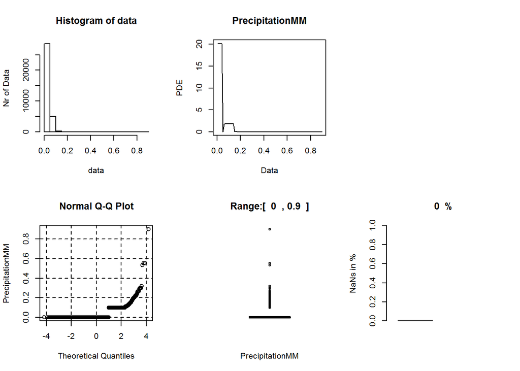

Figure 12: Visuelle Inspektion Precipitation

- Keine NaNs, Es gibt ganz vielen 0,0 und 0,1.
- Wertbereich sehr klein.

Versuche jetzt die Nullen und 0,1 wegzunehmen.

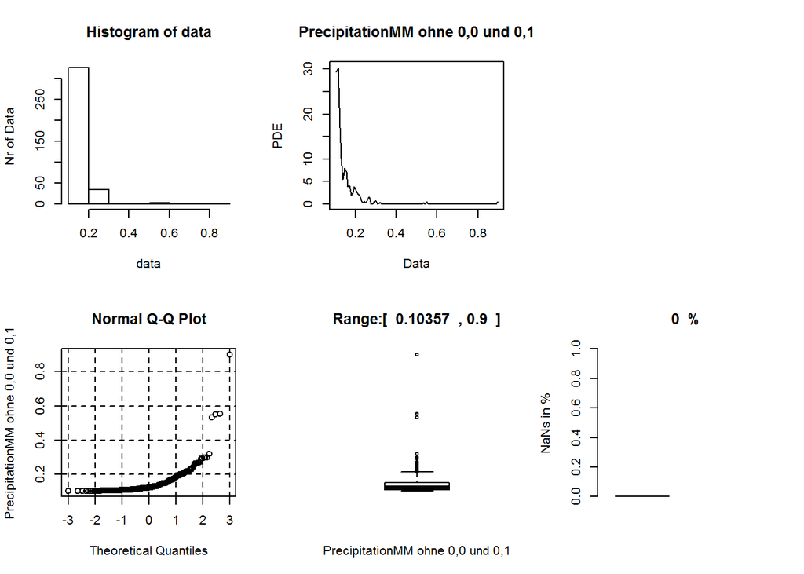

- nach Eliminierung der 0,0 und 0,1 ist der Werte immer noch nicht normalverteilt, Transformation benötigt.
- Wertbereich sehr klein, evtl.prozentuierung.

Nach mehrfach Durfühung der Box-cox Transformation hat Faktor -3,5 als Empfehlung erhalten:

```
## $LambdaMatrix
##        sw   ad cvm   pt   sf   lt   jb   ac
## [1,] -3.5 -3.8  -4 -2.5 -3.5 -3.7 -4.5 -2.6
##
## $boxcoxncData
## $boxcoxncData$title
## [1] "Implementation of Box-Cox Power Transformation when No Covariate Is Available"
##
## $boxcoxncData$method
## [1] "All"
##
## $boxcoxncData$date
## [1] "Thu Jun 16 01:59:28 2016"
##
## $boxcoxncData$result
##                       sw            ad           cvm            pt
## lambda.hat -3.500000e+00 -3.800000e+00 -4.000000e+00 -2.500000e+00
## sw.pvalue   9.923233e-10  8.879470e-10  7.488289e-10  2.807248e-10
## sf.pvalue   1.404679e-08  1.284688e-08  1.109027e-08  4.293853e-09
## jb.pvalue   6.956132e-06  7.710391e-06  8.089340e-06  2.949622e-06
##                       sf            lt            jb            ac
## lambda.hat -3.500000e+00 -3.700000e+00 -4.500000e+00 -2.600000e+00
## sw.pvalue   9.923233e-10  9.404085e-10  3.708628e-10  3.648589e-10
## sf.pvalue   1.404679e-08  1.348224e-08  5.977751e-09  5.466082e-09
## jb.pvalue   6.956132e-06  7.483225e-06  8.550907e-06  3.431206e-06
```

Betrachte daher die Transformation Daten^(-3)

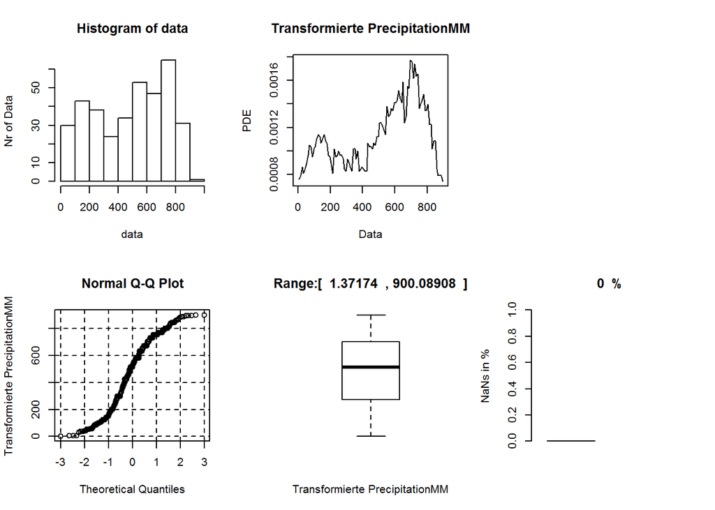

Figure 15: Visuelle Inspektion transformierte Precipitation ohne 0,0 und 0,1.